# Regressão

Lucas Marlon

15 de agosto de 2017

# Sobre os dados

Nesse relatório, vamos utilizar os dados de 5000 encontros relâmpagos ([Speed Dating](http://www.speeddatingbrasil.com.br/o-que-e.php)) de 4 minutos envolvendo 310 jovens americanos. Cada participante tinha vários encontros de 4 minutos por noite. Após cada encontro, eles preenchiam fichas avaliando aqueles com quem se encontraram, e é com os dados desses formulários que vamos trabalhar.

```r
speed.dating = read_csv("./dados/speed-dating.csv")
```

Vamos filtrar os dados e separá-los em dois grupos, o primeiro onde as mulheres avaliam os encontros e o segundo onde os homens que avaliam seus encontros. Além disso, nosso foco será descobrir qual característica, **inteligente** ou **divertido**, tem maior relação com o fato da pessoa, de modo geral, gostar da outra.

As variáveis que vamos usar para realizar nossa análise são:

**like**: representa, de modo geral, o quão uma pessoa gostou da outra;  
**intel**: representa o quão inteligente uma pessoa achou a outra;  
**fun**: representa o quão divertido uma pessoa achou a outra.

# Avaliação das Mulheres

Aqui vamos analisar a relação das características inteligente e divertido com o fato das **mulheres** gostarem das pessoas após o *speed dating*.

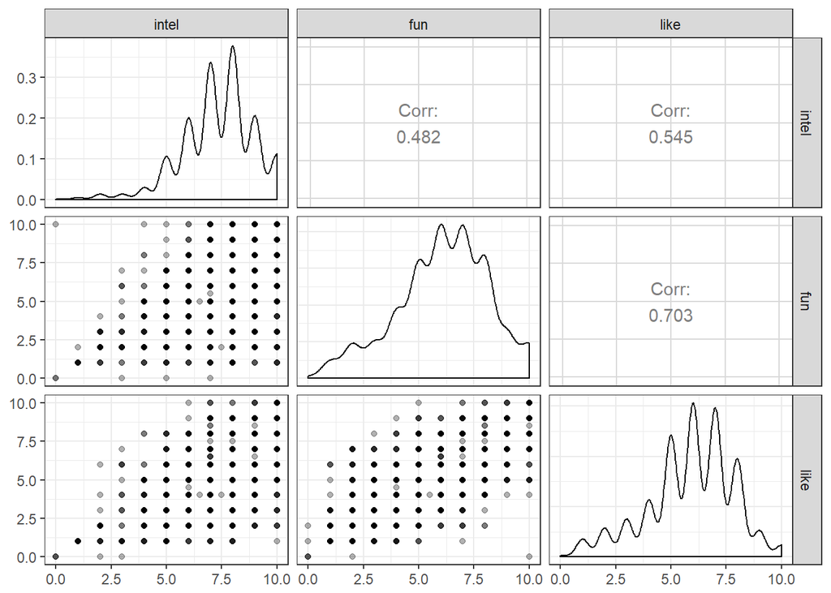

```r
mulheres = speed.dating %>%
  filter(gender == 0, like != 'NA', fun != 'NA', intel != 'NA')

mulheres %>%
  select(intel, fun, like) %>%
  ggpairs(lower = list(continuous = wrap("points", alpha = 0.3)))
```

Acima, já conseguimos observar uma correlação positiva, tanto para característica inteligente (0.545) quanto para divertido (0.703), com o fato das mulheres gostarem da outra pessoa após o *speed dating*.

## Modelo 1 (mulheres)

Para realizar nossa análise vamos considerar os dois preditores ao mesmo tempo no nosso modelo:

```r
mulheres.model = lm(like ~ intel + fun, data = mulheres)

plotar_modelo_mulheres = mulheres %>%
  data_grid(intel = seq_range(intel, 10), # Crie um vetor de 10 valores no range de intel
            fun = seq_range(fun, 4)) %>%  # Vetor de 4 valores no range de fun
  add_predictions(mulheres.model)

glimpse(plotar_modelo_mulheres)
```

```
## Observations: 40
## Variables: 3
## $ intel <dbl> 0.000000, 0.000000, 0.000000, 0.000000, 1.111111, 1.1111...
## $ fun   <dbl> 0.000000, 3.333333, 6.666667, 10.000000, 0.000000, 3.333...
## $ pred  <dbl> 0.3442916, 2.1072860, 3.8702803, 5.6332747, 0.6943066, 2...
```

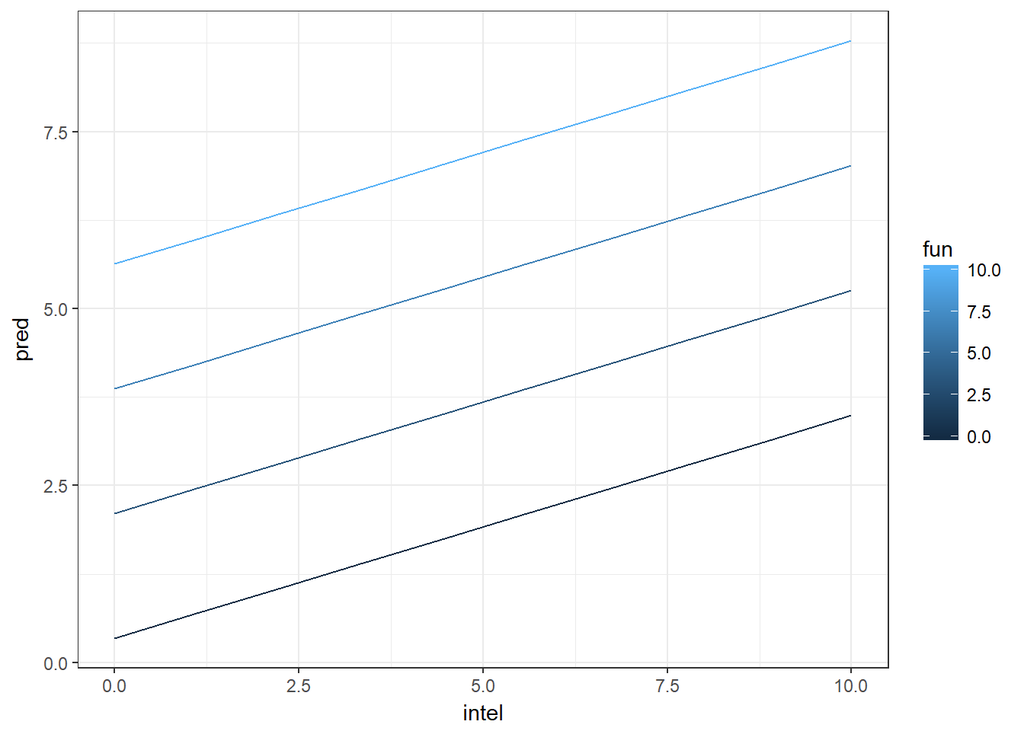

```r
plotar_modelo_mulheres %>%
  ggplot(aes(x = intel, y = pred)) +
  geom_line(aes(group = fun, colour = fun))
```

Inicialmente, vamos visualizar os resíduos em função de cada preditor do modelo 1 (mulheres):

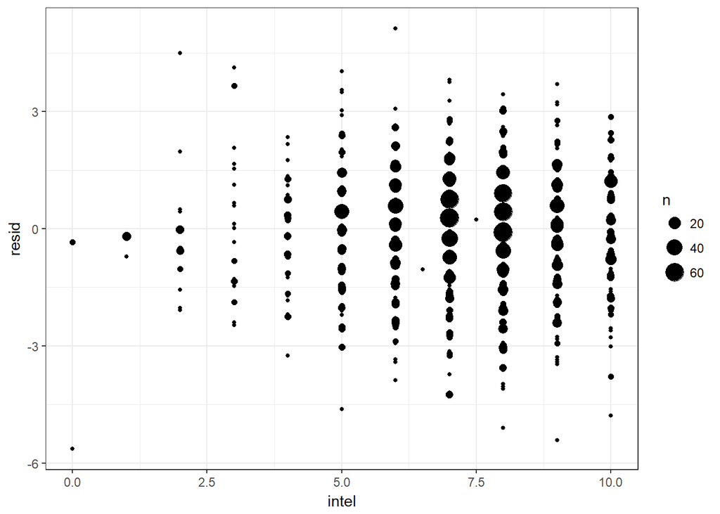

```r
adv_augmented = mulheres %>%
  add_predictions(mulheres.model) %>%
  add_residuals(mulheres.model)

# Resíduos em função de intel
adv_augmented %>%
  ggplot(aes(x = intel)) +
  geom_count(aes(y = resid))
```

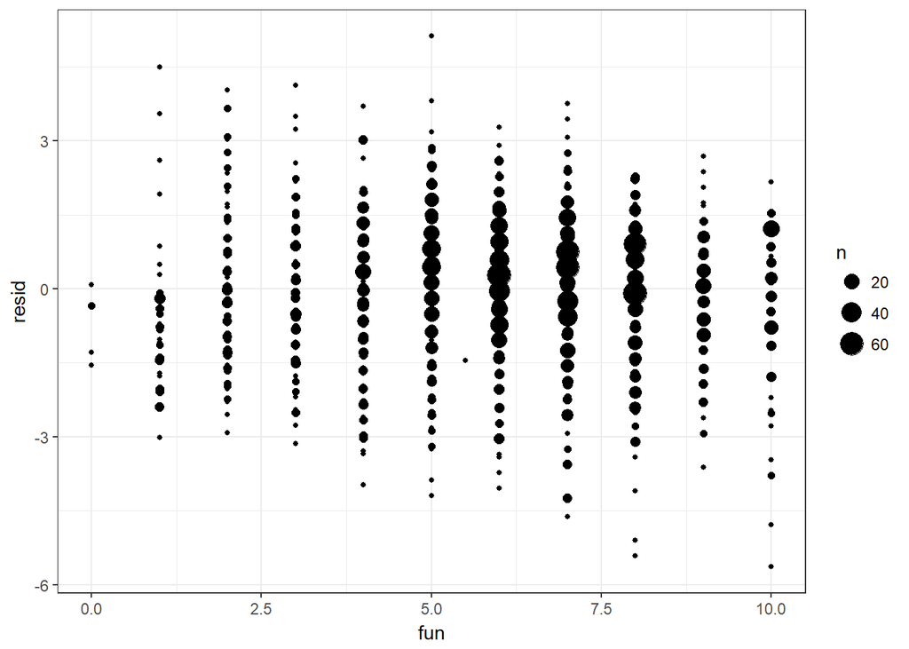

```r
# Resíduos em função de fun
adv_augmented %>%
  ggplot(aes(x = fun)) +
  geom_count(aes(y = resid))
```

Como podemos observar em relação aos resíduos não há nada alarmante em termos de valores extremos, relações obviamente não-lineares e nem heteroscedasticidade, então vamos examinar os coeficientes e o modelo.  
Logo abaixo, se observamos os coeficientes encontrados para o modelo 1 (mulheres), podemos afimar segundo os intervalos de confiança, que as características inteligente (intel) e divertido (fun) são estatisticamente significativas ao fato das mulheres gostarem das pessoas. Sendo a característica divertido quase duas vezes mais relevante que inteligente quando de trata das mulheres, de modo geral, gostarem de alguém.

```r
tidy(mulheres.model, conf.int = TRUE) %>%
  select(-std.error, -p.value)
```

```
##          term  estimate statistic  conf.low conf.high
## 1 (Intercept) 0.3442916  2.779269 0.1013689 0.5872144
## 2       intel 0.3150135 17.044459 0.2787710 0.3512560
## 3         fun 0.5288983 36.216669 0.5002607 0.5575359
```

Nosso modelo 1 (mulheres) consegue explicar aproximadamente 55% da variação dos nossos dados, ou seja, podemos afirmar que nossa variável dependente (like) consegue ser bem explicada pelas características inteligente e divertido.

```r
glance(mulheres.model, conf.int = TRUE)
```

```
##   r.squared adj.r.squared    sigma statistic p.value df    logLik      AIC
## 1 0.5495855     0.5492012 1.291464  1430.048       0  3 -3929.054 7866.108
##        BIC deviance df.residual
## 1 7889.152 3909.506        2344
```

Será que vamos observar resultados semelhantes ao criamos nosso modelos para os homens? Ou será que a inteligência vai ser uma característica mais relevante que a diversão para os homens gostarem das pessoas após os *speed dating*? Vamos averiguar…

# Avaliação dos Homens

Agora vamos analisar a relação das características inteligente e divertido com o fato dos **homens** gostarem das pessoas após o *speed dating*.

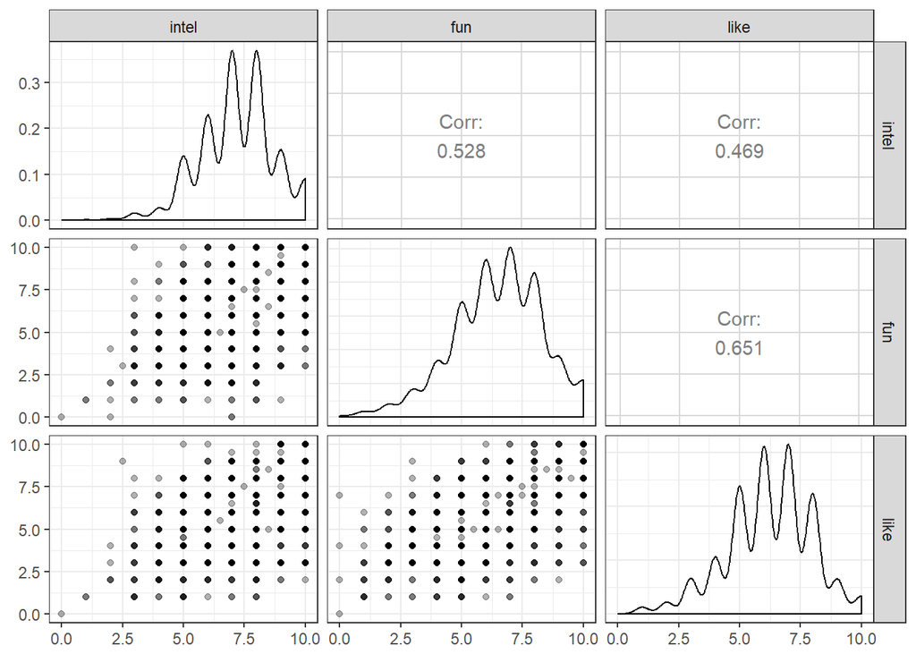

```r
homens = speed.dating %>%
  filter(gender == 1, like != 'NA', fun != 'NA', intel != 'NA')

homens %>%
  select(intel, fun, like) %>%
  ggpairs(lower = list(continuous = wrap("points", alpha = 0.3)))
```

Acima, já conseguimos observar uma correlação positiva, tanto para característica inteligente (0.469) quanto para divertido (0.651), com o fato dos homens gostarem da outra pessoa após o *speed dating*. Comportamento semelhante ao encontrado para o grupo das mulheres.

## Modelo 2 (homens)

Para realizar nossa análise desse modelo também vamos considerar os dois preditores ao mesmo tempo:

```r
homens.model = lm(like ~ intel + fun, data = homens)

plotar_modelo_homens = homens %>%
  data_grid(intel = seq_range(intel, 10), # Cria um vetor de 10 valores no range de intel
            fun = seq_range(fun, 4)) %>%  # Vetor de 4 valores no range de fun
  add_predictions(homens.model)

glimpse(plotar_modelo_homens)
```

```
## Observations: 40
## Variables: 3
## $ intel <dbl> 0.000000, 0.000000, 0.000000, 0.000000, 1.111111, 1.1111...
## $ fun   <dbl> 0.000000, 3.333333, 6.666667, 10.000000, 0.000000, 3.333...
## $ pred  <dbl> 1.340176, 3.105497, 4.870818, 6.636139, 1.561711, 3.3270...
```

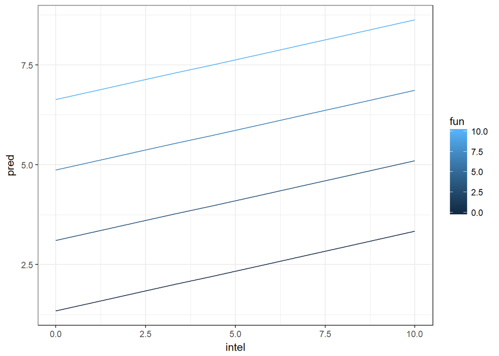

```r
plotar_modelo_homens %>%
  ggplot(aes(x = intel, y = pred)) +
  geom_line(aes(group = fun, colour = fun))
```

Inicialmente, vamos visualizar os resíduos em função de cada preditor do modelo 2 (homens):

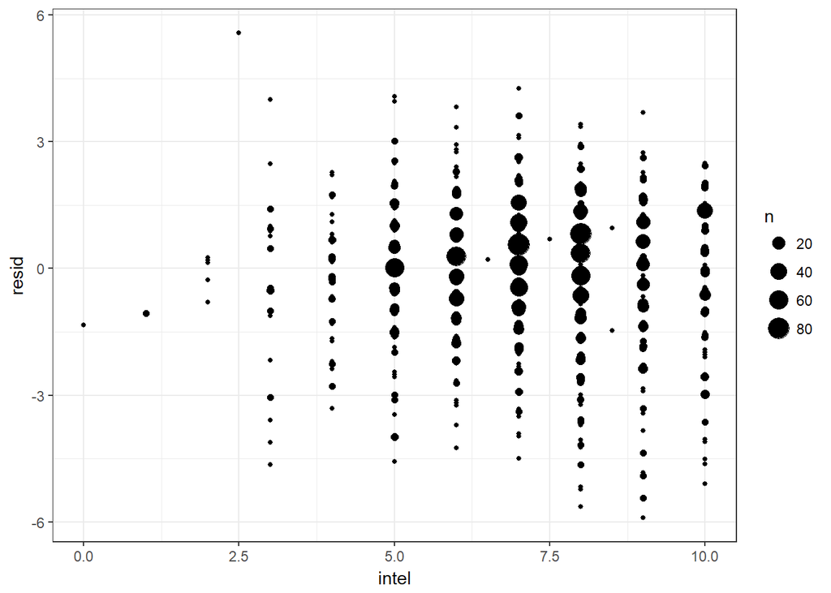

```r
adv_augmented = homens %>%
  add_predictions(homens.model) %>%
  add_residuals(homens.model)

#Resíduos em função de intel
adv_augmented %>%
  ggplot(aes(x = intel)) +
  geom_count(aes(y = resid))
```

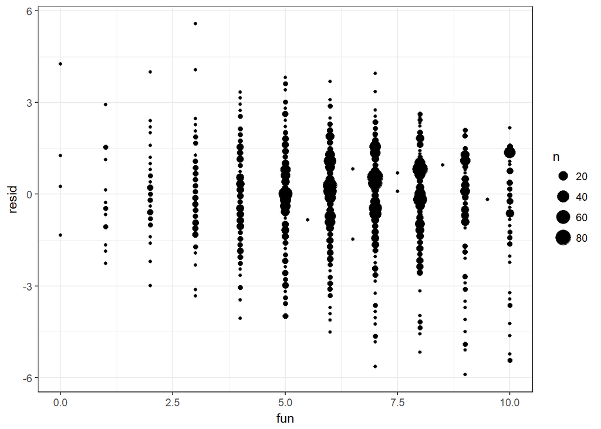

```r
#Resíduos em função de fun
adv_augmented %>%
  ggplot(aes(x = fun)) +
  geom_count(aes(y = resid))
```

Como podemos observar em relação aos resíduos desse modelo 2 (homens) também não há nada alarmante em termos de valores extremos, relações obviamente não-lineares e nem heteroscedasticidade, semelhante ao que encontramos para o nosso modelo 1 (mulheres). Então vamos examinar os coeficientes e o modelo 2 (homens).  
Logo abaixo, se observamos os coeficientes encontrados para modelo 2 (homens), podemos afimar segundo os intervalos de confiança, que as características inteligente (intel) e divertido (fun) são estatisticamente significativas ao fato dos homens gostarem das pessoas, semelhante ao que encontramos no nosso modelo 1 (mulheres). Sendo que para o modelo 2 (homens) a característica divertido é um pouco mais que duas vezes relevante do que a característica inteligente quando de trata dos homens, de modo geral, gostarem de alguém. Ou seja, um pouco maior do quê o que encontramos para o modelo 1 (mulheres).

```r
tidy(homens.model, conf.int = TRUE) %>%
  select(-std.error, -p.value)
```

```
##          term  estimate statistic  conf.low conf.high
## 1 (Intercept) 1.3401757  9.943064 1.0758642 1.6044871
## 2       intel 0.1993814  9.500155 0.1582259 0.2405370
## 3         fun 0.5295963 30.790121 0.4958669 0.5633257
```

Nosso modelo 2 (homens) consegue explicar aproximadamente 44% da variação dos nossos dados. Mesmo sendo uma porcentagem um pouco menor que a encontrada para o nosso modelo 1 (mulheres) ainda podemos afirmar que nossa variável dependente (like) consegue ser bem explicada pelas características inteligente e divertido.

```r
glance(homens.model, conf.int = TRUE)
```

```
##   r.squared adj.r.squared    sigma statistic       p.value df    logLik
## 1 0.4458482     0.4453709 1.296873  934.0938 2.254066e-298  3 -3901.928
##        AIC      BIC deviance df.residual
## 1 7811.856 7834.862 3905.322        2322
```

Após observarmos as conclusões dos nossos dois modelos, as quais nos mostraram resultados semelhantes quando se trata da relação que as características inteligente e divertido tem com o fato das pessoas, de modo geral, gostarem das outros após o *speed dating*, poderíamos até sugerir que as pessoas busquem aprender mais piadas, pois parace que o bom humor chama bastante atenção das pessoas, rsrsrs.  
**#ficaadica =]**